# 2021 Stats and Pitch Characteristics

Pitch Summary

| Pitch Type | Velocity | Release Extension | Release Height | Horizontal Movement | Vertical Movement |
| --- | --- | --- | --- | --- | --- |
| FF | 95.0 | 5.69 | 5.88 | 10.8 | 15.7 |
| SL | 73.3 | 5.49 | 5.73 | -9.5 | 0.2 |
| CH | 73.9 | 5.40 | 5.53 | 17.3 | 8.7 |

# Pitch Comps

Using data since 2015, we were able to generate a list of the most similar pitches to your pitches as they currently stand based on a number of different factors. These include:

- Velocity
- Release Extension
- Release Height
- Movement Profile

### Fastball

Most Similar Pitches

| Pitcher | Pitch Type | Velocity | Release Extension | Release Height | Horizontal Movement | Vertical Movement | Whiff | Barrel | xRV+ |
| --- | --- | --- | --- | --- | --- | --- | --- | --- | --- |
| Mike Adams | FF | 95.0 | 5.69 | 5.88 | 10.80 | 15.70 | NA | NA | NA |
| Brad Brach | FF | 94.6 | 5.70 | 5.89 | 8.28 | 16.20 | 10.9% | 7.9% | 97 |
| Joe Harvey | FF | 95.2 | 5.80 | 5.75 | 12.60 | 15.72 | 10.2% | 12.7% | 104 |
| Luis Perdomo | FF | 94.3 | 5.70 | 5.99 | 9.96 | 14.52 | 2.9% | 7.6% | 102 |
| Evan Marshall | FF | 93.6 | 5.70 | 5.92 | 9.96 | 14.52 | 7.3% | 5.0% | 98 |
| Michael Lorenzen | FF | 95.6 | 5.90 | 5.88 | 10.92 | 17.16 | 7.0% | 5.0% | 103 |

### Slider

Most Similar Pitches

| Pitcher | Pitch Type | Velocity | Release Extension | Release Height | Horizontal Movement | Vertical Movement | Whiff | Barrel | xRV+ |
| --- | --- | --- | --- | --- | --- | --- | --- | --- | --- |
| Mike Adams | SL | 73.3 | 5.49 | 5.73 | -9.50 | 0.20 | NA | NA | NA |
| Matt Shoemaker | KC | 75.7 | 5.70 | 6.43 | -10.08 | 0.12 | 3.3% | 5.4% | 106 |
| Julio Teheran | CU | 72.9 | 5.60 | 5.21 | -10.68 | -4.32 | 11.1% | 7.9% | 102 |
| Yusmeiro Petit | CU | 76.9 | 6.60 | 5.80 | -10.80 | 4.56 | 20.5% | 3.9% | 92 |
| Josh Lindblom | SL | 76.1 | 6.20 | 5.91 | -15.36 | 0.00 | 19.6% | 0.0% | 106 |
| Adam Cimber | SL | 77.0 | 6.20 | 2.05 | -2.88 | 3.60 | 11.5% | 6.7% | 103 |

### Change-Up

Most Similar Pitches

| Pitcher | Pitch Type | Velocity | Release Extension | Release Height | Horizontal Movement | Vertical Movement | Whiff | Barrel | xRV+ |
| --- | --- | --- | --- | --- | --- | --- | --- | --- | --- |
| Mike Adams | CH | 73.9 | 5.4 | 5.53 | 17.30 | 8.70 | NA | NA | NA |
| Jacob Webb | CH | 83.9 | 6.0 | 5.51 | 18.00 | 8.40 | 23.2% | 2.4% | 99 |
| Brandon Kintzler | CH | 87.6 | 6.4 | 5.93 | 16.68 | 9.24 | 13.6% | 3.2% | 97 |
| Dane Dunning | CH | 85.6 | 6.5 | 5.83 | 15.60 | 8.88 | 10.3% | 16.0% | 101 |
| Cristian Javier | CH | 86.0 | 6.0 | 5.35 | 15.96 | 9.12 | 6.8% | 4.0% | 91 |
| Daniel Mengden | CH | 82.0 | 6.1 | 6.00 | 15.48 | 8.64 | 5.7% | 5.7% | 105 |

# Ideal Pitch Locations

We pulled the 1,000 most similar pitches thrown since 2015 and generated a heat map of the Swinging Strike Rate by location for those pitches most similar to yours. Additionally, we took the 500 most similar pitches that were put in play and built a heat map for barrels. If you are not familiar with barrels, it is a measure of ideal exit velocity/launch angle combinations. When determining where to focus on locating your pitches, refer to these heat maps.

# Fastballs (Based off 2021 averages)

[figure not shown]

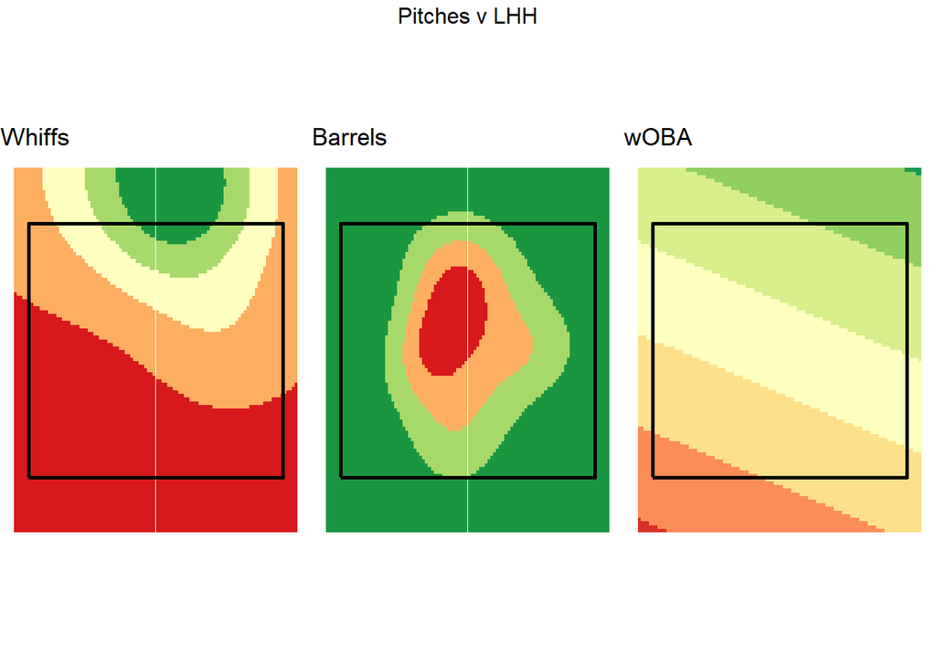

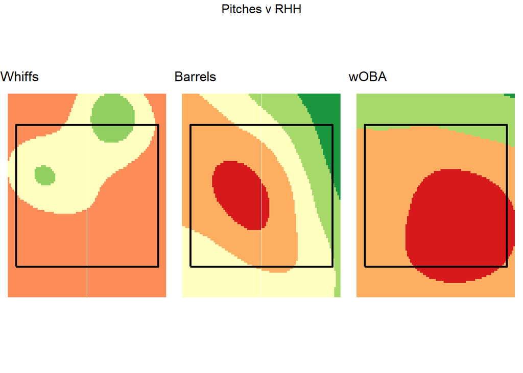

# Slider (Based off 2021 averages)

[figure not shown]

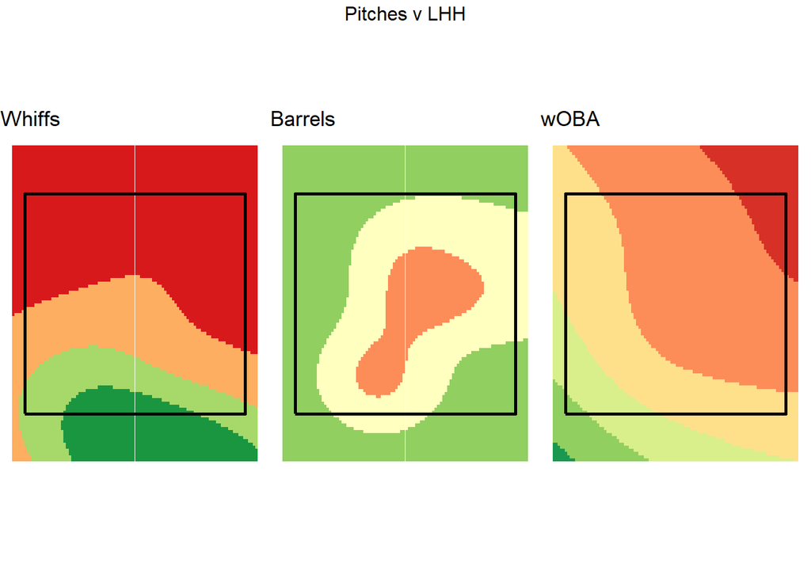

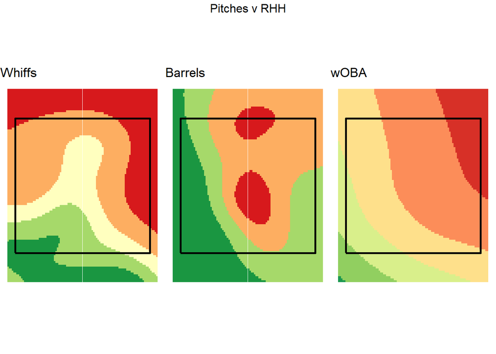

# Change-Up (Based off 2021 averages)

[figure not shown]

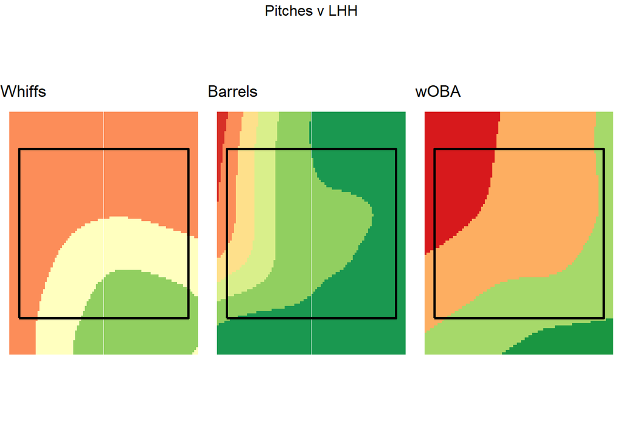

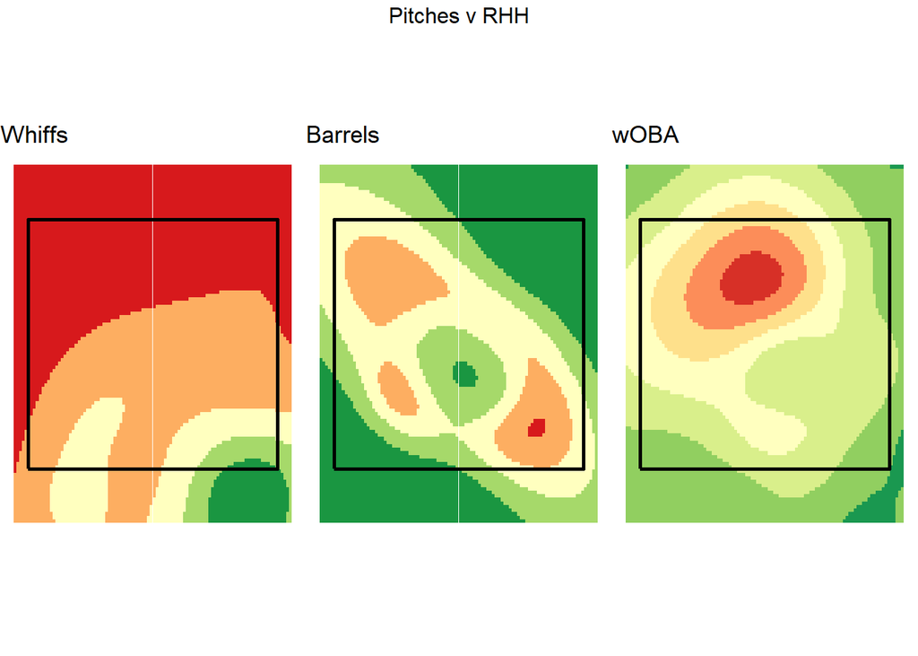

# Overall Summary

## Pitch Locations

Based off the overall movement profile of your pitches here are what we believe are the areas you should be attacking with each of your pitches versus both left and right handed hitters. The green areas are location where you are likely to get a swing a miss than allow a barrel. The outlined green area is the whiff zone and the red outlined areas are the danger zones to avoid.

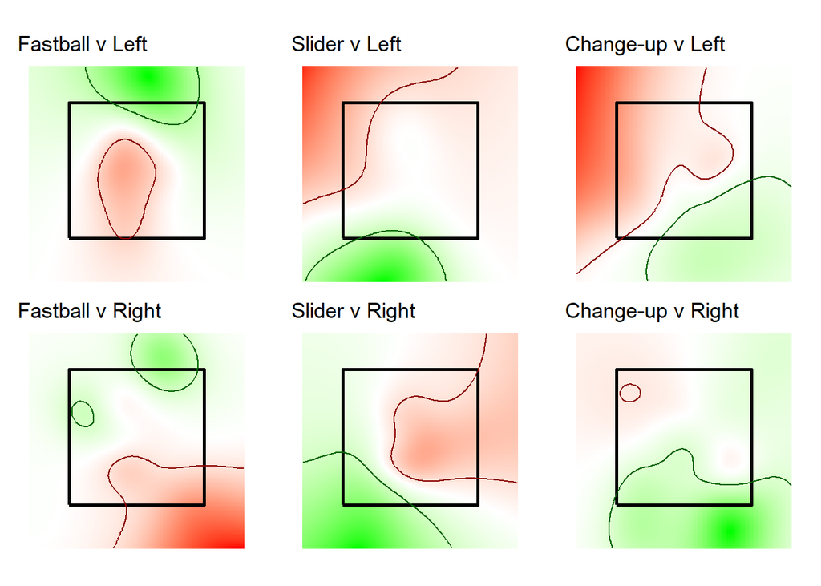